# Crossword Comparison

## Introduction

This was another project I did when I was first starting to play around with python and trying to get better at string and list manipulation. I enjoy doing crosswords and have always been curious if crossword authors ever reuse blocks or patterns from older puzzles. To test that, I built a function to compare crosswords to identify shared substructures - or "motifs" as I call them here.

NOTE: A while back a software engineer was doing similar analysis and uncovered a plagiarism scandal in the crossword world that made national news. By analyzing thousands of crosswords from multiple publishers, they discovered that hundreds of puzzles - all edited by same person - that were either duplicates or near duplicates of older puzzles. When republished, the "new" puzzle was attributed to different author - often fictious. While that analysis was focused on identifying wholesale plagiarism, my approach was to look for repeated motifs.

## Data & Background

To get started, I loaded a few packages along with the crossword data. The data set for this project was compiled by Dylan O'Shea and hosted on his [github](https://github.com/doshea/nyt_crosswords). It includes more than 14,000 crossword puzzles published by the New York Times between 1976 and 2018 - with a few gaps in coverage. The crosswords are stored as json files and organized into folders according to when the puzzle was published.

```python
import pandas            as pd
import numpy             as np
import matplotlib.pyplot as plt
import glob
import os
import json

from datetime           import datetime
from itertools          import combinations

# Get all JSON file paths recursively
json_files = glob.glob(os.path.join('C:\\Users\\u6036288\\Desktop\\Personal\\Python Projects\\Crosswords', '**', '*.json'), recursive = True)

# Load all JSON files
crossword_data = []

for i in json_files:
    try:
        with open(i) as file:
            crossword_data.append(json.load(file))
    except json.JSONDecodeError:
        print(f"Skipping invalid JSON: {i}")
```

## Comparing Crossword Puzzles

The function below compares two crossword puzzles by looking for shared motifs. First, the function breaks down each puzzle into a series of motifs, where the size of the motif is determined the the window size argument. The design is effectively a sliding window algorithm. Starting in the top left corner of the crossword, we record the values in that window. We then move the window one column to the right and repeat the process. When we reach the end of the row, we move one column down and repeat the process. Then, the function compares all of the motifs in the first crossword to all of the motifs in the second puzzle. Any repeated motifs are returned along with the author, date, and grid of both puzzles.

```python
def crossword_comparison(crossword_1, crossword_2, window_size = 4):

    ## extracting data from the older crossword

    crossword_1_author = crossword_1['author']
    crossword_1_date   = crossword_1['date']

    crossword_1_grid   = crossword_1['grid']
    crossword_1_cols   = crossword_1['size']['cols']
    crossword_1_rows   = crossword_1['size']['rows']

    ## extracting data from the newer crossword

    crossword_2_author = crossword_2['author']
    crossword_2_date   = crossword_2['date']

    crossword_2_grid   = crossword_2['grid']
    crossword_2_cols   = crossword_2['size']['cols']
    crossword_2_rows   = crossword_2['size']['rows']

    ## crossword 1 motifs

    crossword_1_motifs = []

    for i in range(0, (1 + crossword_1_cols - window_size)):

        for j in range(0, (1 + crossword_1_rows - window_size)):

            temp_motif = []

            for k in range(0, window_size):

                temp_motif_item = crossword_1_grid[(j+(i*crossword_1_rows)+(k*crossword_1_rows)):((j+(i*crossword_1_rows)+(k*crossword_1_rows))+window_size)]

                temp_motif = temp_motif + temp_motif_item

            crossword_1_motifs.append(temp_motif)


    ## crossword 2 motifs

    crossword_2_motifs = []

    for i in range(0, (1 + crossword_2_cols - window_size)):

        for j in range(0, (1 + crossword_2_rows - window_size)):

            temp_motif = []

            for k in range(0, window_size):

                temp_motif_item = crossword_2_grid[(j+(i*crossword_2_rows)+(k*crossword_2_rows)):((j+(i*crossword_2_rows)+(k*crossword_2_rows))+window_size)]

                temp_motif = temp_motif + temp_motif_item

            crossword_2_motifs.append(temp_motif)


    ## checking to see if any motiffs in the focal crossword are in other crossword

    temp_copied_motifs = [x for x in crossword_2_motifs if x in crossword_1_motifs and set(x) != set('.')]

    if len(temp_copied_motifs) > 0:

        if pd.to_datetime(crossword_1_date) < pd.to_datetime(crossword_2_date):

            old_crossword_author = crossword_1_author
            old_crossword_date   = crossword_1_date
            old_crossword_grid   = crossword_1_grid
            old_crossword_cols   = crossword_1_cols

            new_crossword_author = crossword_2_author
            new_crossword_date   = crossword_2_date
            new_crossword_grid   = crossword_2_grid
            new_crossword_cols   = crossword_2_cols

            reused_motifs = [[old_crossword_author, old_crossword_date, old_crossword_grid, old_crossword_cols], [new_crossword_author, new_crossword_date, new_crossword_grid, new_crossword_cols], temp_copied_motifs]

            return reused_motifs

        else:

            old_crossword_author = crossword_2_author
            old_crossword_date   = crossword_2_date
            old_crossword_grid   = crossword_2_grid
            old_crossword_cols   = crossword_2_cols

            new_crossword_author = crossword_1_author
            new_crossword_date   = crossword_1_date
            new_crossword_grid   = crossword_1_grid
            new_crossword_cols   = crossword_1_cols

            reused_motifs = [[old_crossword_author, old_crossword_date, old_crossword_grid, old_crossword_cols], [new_crossword_author, new_crossword_date, new_crossword_grid, new_crossword_cols], temp_copied_motifs]

            return reused_motifs
```

And after testing the function on some sample data, we can loop over every unique combination of puzzles. However, with more than 14K puzzles, it is going to take some time.

```python
## looping over pairs of crosswords

reused_motifs = []

for i in range(0, len(crossword_data)):

    for j in range(i+1, len(crossword_data)):

        temp_reused_motifs = crossword_comparison(crossword_1 = crossword_data[i], crossword_2 = crossword_data[j], window_size = 4)

        if type(temp_reused_motifs) is list:

            reused_motifs.append(temp_reused_motifs)


    if i % 1000 == 0:
        print(i)
```

## Plotting Crosswords

The code below loops over the results of our crossword comparison function and plots the puzzles side-by-side: the original puzzle on the left and the newer puzzle on the right. Shared motifs are highlighted green and any other shared letters are highlighted yellow.

```python
plots = []

for i in range(len(reused_motifs)):

    ##########
    ## DATA ##
    ##########

    ## extracting crossword data
    cw_1_auth = reused_motifs[i][0][0]
    cw_1_date = reused_motifs[i][0][1]
    cw_1_rows = int(len(reused_motifs[i][0][2])/reused_motifs[i][0][3])
    cw_1_cols = reused_motifs[i][0][3]
    cw_1_puzz = reused_motifs[i][0][2]

    cw_2_auth = reused_motifs[i][1][0]
    cw_2_date = reused_motifs[i][1][1]
    cw_2_rows = int(len(reused_motifs[i][1][2])/reused_motifs[i][1][3])
    cw_2_cols = reused_motifs[i][1][3]
    cw_2_puzz = reused_motifs[i][1][2]

    ## reshaping grid data
    cw_1_grid = np.array(cw_1_puzz).reshape(cw_1_rows, cw_1_cols)
    cw_2_grid = np.array(cw_2_puzz).reshape(cw_2_rows, cw_2_cols)

    ## Need to get position of each motiff in both puzzles
    window_size          = int(np.sqrt(len(reused_motifs[i][2][0])))
    cw_1_motif_positions = []
    cw_2_motif_positions = []

    for j in range(0, (1 + cw_1_rows - window_size)):

        for l in range(0, (1 + cw_1_cols - window_size)):

            temp_motif = []

            for m in range(0, window_size):

                temp_motif_item = cw_1_puzz[(l+(j*cw_1_rows)+(m*cw_1_rows)):((l+(j*cw_1_rows)+(m*cw_1_rows))+window_size)]

                temp_motif = temp_motif + temp_motif_item

            if temp_motif in reused_motifs[i][2]:

                temp_pos = [[x, y] for x in list(range(j, j+window_size)) for y in list(range(l, l+window_size))]

                cw_1_motif_positions = cw_1_motif_positions + temp_pos

    for j in range(0, (1 + cw_2_rows - window_size)):

        for l in range(0, (1 + cw_2_cols - window_size)):

            temp_motif = []

            for m in range(0, window_size):

                temp_motif_item = cw_2_puzz[(l+(j*cw_2_rows)+(m*cw_2_rows)):((l+(j*cw_2_rows)+(m*cw_2_rows))+window_size)]

                temp_motif = temp_motif + temp_motif_item


            if temp_motif in reused_motifs[i][2]:

                temp_pos = [[x, y] for x in list(range(j, j+window_size)) for y in list(range(l, l+window_size))]

                cw_2_motif_positions = cw_2_motif_positions + temp_pos


    ##########
    ## PLOT ##
    ##########

    fig, (fig_1, fig_2) = plt.subplots(1, 2, figsize=(12, 6.5))

    # plotting crossword #1
    for j in range(cw_1_cols):

        for l in range(cw_1_rows):

            val = cw_1_grid[j][l]

            # black squares for black squares
            if val in ['.']:

                fig_1.add_patch(plt.Rectangle((l, cw_1_cols - 1 - j), 1, 1, color = 'black'))

            ## green squares for reused motifs
            elif [j, l] in cw_1_motif_positions:

                fig_1.add_patch(plt.Rectangle((l, cw_1_cols - 1 - j), 1, 1, edgecolor = 'black', facecolor = 'green'))
                fig_1.text(l + 0.5, cw_1_cols - 0.5 - j, val, ha = 'center', va = 'center', fontsize = 14, family = 'monospace')

            ## white squares for everything else
            else:

                fig_1.add_patch(plt.Rectangle((l, cw_1_cols - 1 - j), 1, 1, edgecolor = 'black', facecolor = 'white'))
                fig_1.text(l + 0.5, cw_1_cols - 0.5 - j, val, ha = 'center', va = 'center', fontsize = 14, family = 'monospace')

    # plotting crossword #2
    for j in range(cw_2_cols):

        for l in range(cw_2_rows):

            val = cw_2_grid[j][l]

            ## black squares for black squares
            if val in ['.']:

                fig_2.add_patch(plt.Rectangle((l, cw_2_cols - 1 - j), 1, 1, color = 'black'))

            ## green squares for reused motifs
            elif [j, l] in cw_2_motif_positions:

                fig_2.add_patch(plt.Rectangle((l, cw_2_cols - 1 - j), 1, 1, edgecolor = 'black', facecolor = 'green'))
                fig_2.text(l + 0.5, cw_2_cols - 0.5 - j, val, ha = 'center', va = 'center', fontsize = 14, family = 'monospace')

            ## yellow squares where the letters at the same position match
            elif cw_1_grid[j][l] == cw_2_grid[j][l]:

                fig_2.add_patch(plt.Rectangle((l, cw_2_cols - 1 - j), 1, 1, edgecolor = 'black', facecolor = 'yellow'))
                fig_2.text(l + 0.5, cw_2_cols - 0.5 - j, val, ha = 'center', va = 'center', fontsize = 14, family = 'monospace')

            ## white squares for everything else
            else:

                fig_2.add_patch(plt.Rectangle((l, cw_2_cols - 1 - j), 1, 1, edgecolor = 'black', facecolor = 'white'))
                fig_2.text(l + 0.5, cw_2_cols - 0.5 - j, val, ha = 'center', va = 'center', fontsize = 14, family = 'monospace')

    ## plot
    fig_1.axis('off')
    fig_1.set_xlim(0, cw_1_cols)
    fig_1.set_ylim(0, cw_1_rows)
    fig_1.set_aspect('equal')
    fig_1.set_title(f"Author: {cw_1_auth} Date: {cw_1_date}", fontsize = 12, loc = "left")

    fig_2.axis('off')
    fig_2.set_xlim(0, cw_2_cols)
    fig_2.set_ylim(0, cw_2_rows)
    fig_2.set_aspect('equal')
    fig_2.set_title(f"Author: {cw_2_auth} Date: {cw_2_date}", fontsize = 12, loc = "left")

    ##
    plots.append(fig)
    plt.savefig(f"Plots//plot_{i}.png")
    plt.close(fig)
```

## Results

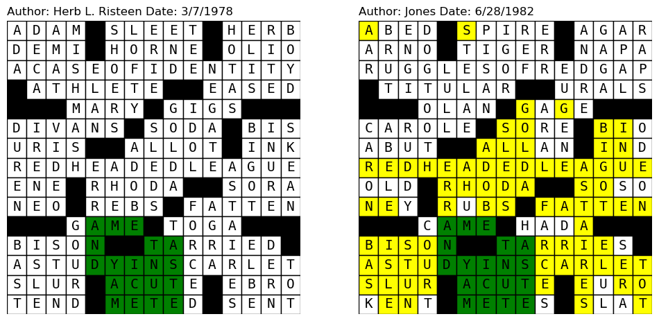

```python
plots[2]
```

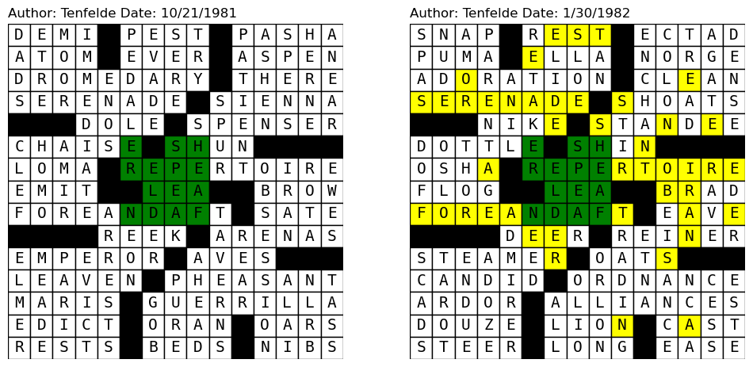

```python
plots[3]
```

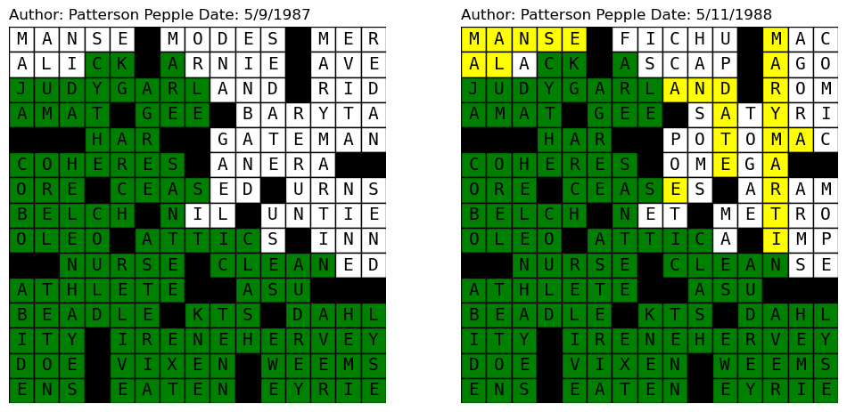

```python
plots[5]
```

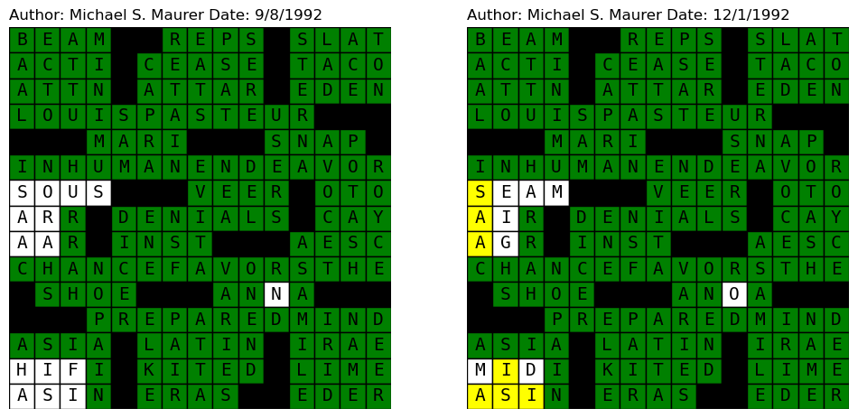

```python
plots[12]
```

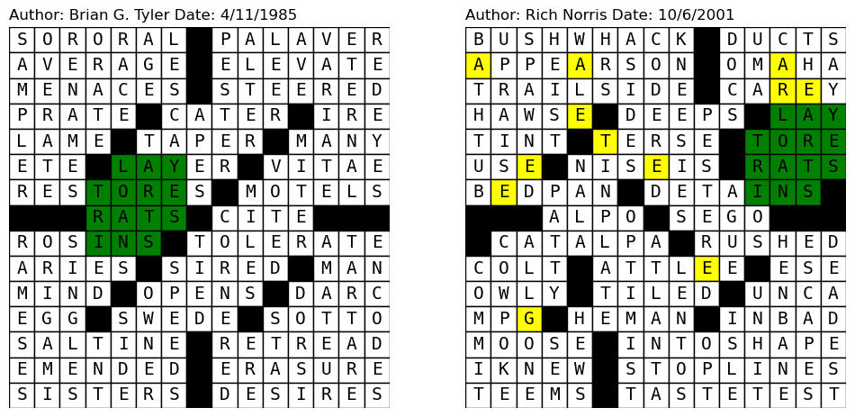

```python
plots[4]
```

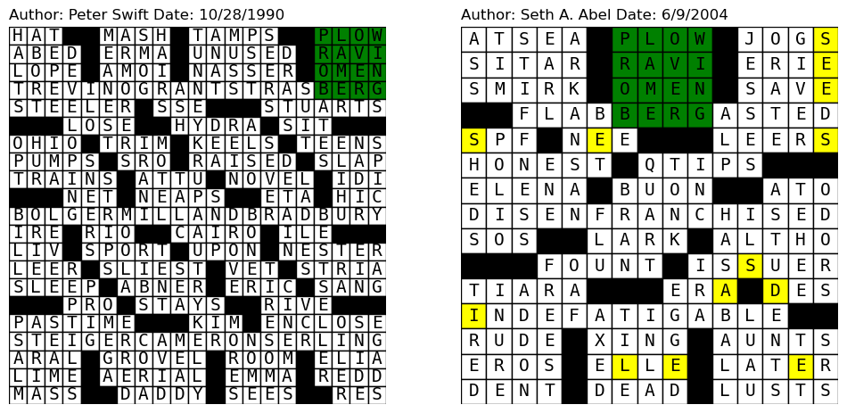

```python
plots[9]
```

## Conclusion & Next Steps

While I wasn't able to detect any widespread resuse of crossword motifs, the function performed as intended - so this goes in the win column.